# Neurological condition analysis

```r
library(tidyverse)
library(readxl)
library(DT)
library(rcartocolor)
library(gghighlight)
library(cowplot)
library(broom)
library(icd)
library(tableone)

theme_set(theme_bw() +
            theme(legend.title = element_blank(),
                  panel.grid.minor = element_blank()))
for (r_file in list.files('R/', full.names = TRUE)) source(r_file)
```

```r
 clin_raw <- read_csv('../../Phase2.1/Date_Shifted_Files/LocalPatientClinicalCourse_Shift.csv')
 demo_raw <- read_csv(
    '../../Phase2.1/Date_Shifted_Files/LocalPatientSummary_Shift.csv',
                       na = '1900-01-01')
 obs_raw <- read_csv('../../Phase2.1/LocalPatientObservations.csv')
```

```r
#clin_raw <-
#  read_csv(
#    '../thrombotic-penn/data/LocalPatientClinicalCourse.csv',
#    col_types = list(patient_num = col_character())
#  )
#demo_raw <-
#  read_csv(
#    '../thrombotic-penn/data/LocalPatientSummary.csv',
#    col_types = list(patient_num = col_character()),
#    na = '1900-01-01'
#  )
#obs_raw <-
#  read_csv(
#    '../thrombotic-penn/data/LocalPatientObservations.csv',
#    col_types = list(patient_num = col_character())
#  )
```

```r
loinc <- read_csv('public-data/loinc-map.csv')
neuro_icds_10 <- read_excel('public-data/2020-09-10_neuro-icd10.xlsx') %>%
  rename('icd' = `ICD-10`)
```

## Data pre-processing

In this initial analysis, we will consider neuro patients as those with a neuro code on the day **of** or **anytime after** their first day of admission. These patients developed neurological conditions after COVID-19 related admission.

Only examining ICD-10 for now.

*Note: We will need to discuss whether we want to include codes assigned on the day of admission as comorbidities.*

```r
neuro_patients <- obs_raw %>%
  filter(
    days_since_admission >= 0,
    concept_code %in% neuro_icds_10$icd) %>%
  distinct(patient_num, concept_code)

neuro_pt_post <- unique(neuro_patients$patient_num)

non_neuro_patients <- data.frame(
  patient_num = setdiff(demo_raw$patient_num, neuro_pt_post)) %>%
  mutate(concept_code = 'NN')

readmissions <- clin_raw %>%
  group_by(patient_num) %>%
  mutate(delta_hospitalized = diff(c(in_hospital[1], in_hospital))) %>%
  ungroup() %>%
  filter(delta_hospitalized != 0,
         in_hospital == 1) %>%
  add_count(patient_num, name = 'n_readmissions') %>%
  # add_count(patient_num, name = 'status_changes') %>%
  # filter(status_changes > 1) %>%
  # mutate(n_readmissions = (status_changes - 1)/2) %>%
  arrange(desc(n_readmissions))

length(unique(readmissions$patient_num))
```

```
## [1] 305
```

```r
re_admin_stats <- readmissions %>%
  select(patient_num, n_readmissions) %>%
  distinct() %>%
  count(n_readmissions)

re_admin_stats
```

```
## # A tibble: 8 x 2
##   n_readmissions     n
##            <int> <int>
## 1              1   219
## 2              2    50
## 3              3    19
## 4              4     9
## 5              5     4
## 6              6     2
## 7              8     1
## 8              9     1
```

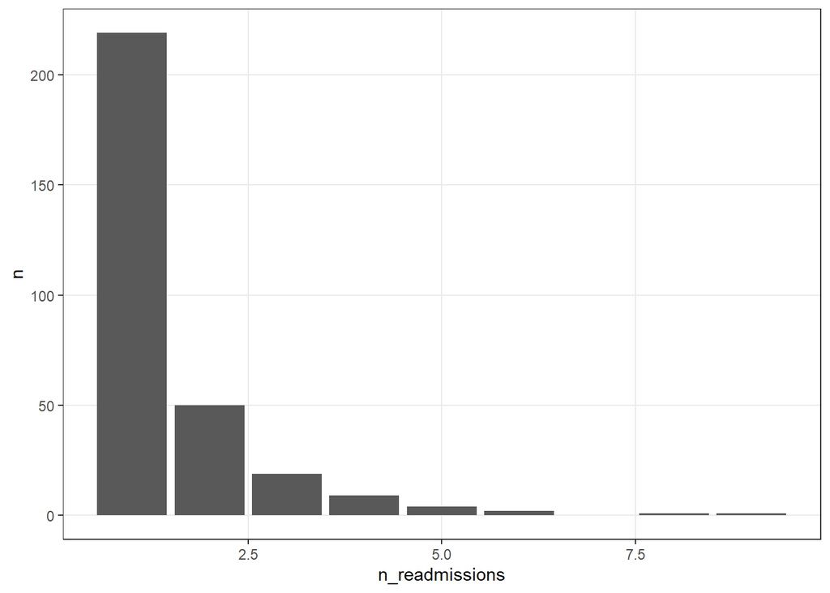

```r
re_admin_stats %>%
  ggplot() +
  geom_col(aes(x = n_readmissions, y = n))
```

```r
days_count_min_max <- obs_raw %>%
  group_by(patient_num) %>%
  summarise(
    distinct_days = n_distinct(days_since_admission),
    min_hos = min(days_since_admission),
    # n_stay = max(days_since_admission),
    .groups = 'drop'
  )

demo_df <- demo_raw %>%
  mutate(time_to_severe = severe_date - admission_date,
         time_to_severe = ifelse(time_to_severe < 0, NA, time_to_severe),
         time_to_death = death_date - admission_date,
         time_to_death = ifelse(time_to_death < 0, NA, time_to_death),
         readmitted = patient_num %in% readmissions$patient_num,
         neuro_post = patient_num %in% neuro_pt_post %>%
           as.factor() %>%
           fct_recode(`Has neurological condition` = "TRUE",
                      `No neurological condition` = "FALSE"),
         Survival = as.factor(deceased) %>%
           fct_recode(Alive = "0", Deceased = "1"),
         sex = as.factor(sex),
         race = as.factor(race),
         age_group = as.factor(age_group),
         Severity = as.factor(severe) %>%
           fct_recode(Severe = "1", `Non-severe` = "0"),
         n_stay = as.numeric(last_discharge_date - admission_date,
                             units="days")) %>%
  left_join(days_count_min_max, by = 'patient_num')
```

## Demographics (Table 1)

```r
formatted_demo <- demo_df %>%
  select(Sex = sex, `Age group` = age_group,
         Race = race, Severity, Survival,
         `Time to severity onset (days)` = time_to_severe,
         `Time to death (days)` = time_to_death,
         Readmitted = readmitted, neuro_post)

## export table 1 to csv
table_one_vars <- setdiff(colnames(formatted_demo), 'neuro_post')
demo_table <- tableone::CreateTableOne(
  data = formatted_demo,
  vars = table_one_vars,
  strata= "neuro_post")

table_one <- print(
  demo_table,
  showAllLevels = TRUE,
  formatOptions = list(big.mark = ","),
  printToggle = FALSE
)

## print table 1 html
table1::table1(
  ~ Sex + `Age group` + Race + Severity + Survival + Readmitted +
    `Time to severity onset (days)` + `Time to death (days)`
  | neuro_post,
  data = formatted_demo,
  overall = "Total",
  export = "results/demographics.csv")
```

|  | No neurological condition (N=2064) | Has neurological condition (N=711) | Total (N=2775) |
| --- | --- | --- | --- |
| Sex |  |  |  |
| female | 1055 (51.1%) | 339 (47.7%) | 1394 (50.2%) |
| male | 1009 (48.9%) | 372 (52.3%) | 1381 (49.8%) |
| Age group |  |  |  |
| 00to02 | 7 (0.3%) | 0 (0%) | 7 (0.3%) |
| 06to11 | 3 (0.1%) | 0 (0%) | 3 (0.1%) |
| 12to17 | 6 (0.3%) | 0 (0%) | 6 (0.2%) |
| 18to25 | 103 (5.0%) | 17 (2.4%) | 120 (4.3%) |
| 26to49 | 673 (32.6%) | 143 (20.1%) | 816 (29.4%) |
| 50to69 | 797 (38.6%) | 264 (37.1%) | 1061 (38.2%) |
| 70to79 | 260 (12.6%) | 141 (19.8%) | 401 (14.5%) |
| 80plus | 215 (10.4%) | 146 (20.5%) | 361 (13.0%) |
| Race |  |  |  |
| american_indian | 3 (0.1%) | 1 (0.1%) | 4 (0.1%) |
| asian | 77 (3.7%) | 34 (4.8%) | 111 (4.0%) |
| black | 347 (16.8%) | 169 (23.8%) | 516 (18.6%) |
| hawaiian_pacific_islander | 11 (0.5%) | 3 (0.4%) | 14 (0.5%) |
| other | 347 (16.8%) | 111 (15.6%) | 458 (16.5%) |
| white | 1279 (62.0%) | 393 (55.3%) | 1672 (60.3%) |
| Severity |  |  |  |
| Non-severe | 1151 (55.8%) | 220 (30.9%) | 1371 (49.4%) |
| Severe | 913 (44.2%) | 491 (69.1%) | 1404 (50.6%) |
| Survival |  |  |  |
| Alive | 1929 (93.5%) | 614 (86.4%) | 2543 (91.6%) |
| Deceased | 135 (6.5%) | 97 (13.6%) | 232 (8.4%) |
| Readmitted |  |  |  |
| Yes | 172 (8.3%) | 133 (18.7%) | 305 (11.0%) |
| No | 1892 (91.7%) | 578 (81.3%) | 2470 (89.0%) |
| Time to severity onset (days) |  |  |  |
| Mean (SD) | 7.58 (22.7) | 7.79 (23.4) | 7.65 (22.9) |
| Median [Min, Max] | 0 [0, 179] | 0 [0, 188] | 0 [0, 188] |
| Missing | 1151 (55.8%) | 220 (30.9%) | 1371 (49.4%) |
| Time to death (days) |  |  |  |
| Mean (SD) | 13.7 (13.2) | 28.6 (30.6) | 19.9 (23.3) |
| Median [Min, Max] | 10.0 [0, 93.0] | 20.0 [1.00, 160] | 13.0 [0, 160] |
| Missing | 1929 (93.5%) | 614 (86.4%) | 2543 (91.6%) |

## Comorbidity

```r
n_patients <- nrow(demo_raw)
obs_raw <- obs_raw %>%
  filter(concept_type %in% c("DIAG-ICD10", "DIAG-ICD9"))
```

New variable `neuro_post` to indicate whether the patient developed neurological conditions after COVID-19 related admission.

Q: What about on the day of? (==0)

```r
table(demo_df$neuro_post)
```

```
##
##  No neurological condition Has neurological condition
##                       2064                        711
```

## Map comorbidities

List of comorbidity abbreviations for reference purposes, then run the `map_charlson_codes()` function:

```r
# for charlson or quan-deyo
comorb_names <- get_charlson_names()
comorbs <- as.vector(comorb_names$Abbreviation)

# for elixhauser
comorb_names_elix <- get_quan_elix_names()
comorbs_elix <- as.vector(comorb_names_elix$Abbreviation)

# t1: earliest time point to consider comorbidities
# t2: latest time point to consider comorbidities
# example <- t1 = -365, and t2 = -1 will map all all codes up to a year prior but before admission (admission = day 0)
comorb <- map_charlson_codes(df = obs_raw,
                             comorb_names = comorb_names,
                             t1 = -365,
                             t2 = -15,
                             map_type = 'charlson')

comorb_elix <- map_charlson_codes(df = obs_raw,
                                  comorb_names = comorb_names_elix,
                                  t1 = -365,
                                  t2 = -15,
                                  map_type = 'elixhauser')
```

`map_charlson_codes()` outputs a 2-element lists:

1- Dataframe of the Charlson comorbidity index scores

2- Dataframe of the specific mapped codes arranged by frequency. Comorbidity mapping of all patients with ICD codes prior to admission, regardless of whether or not they had a comorbidity.

```r
# charlson
index_scores <- comorb$index_scores
mapped_codes_table <- comorb$mapped_codes_table
comorb_names$Abbreviation <- as.character(comorb_names$Abbreviation)

# elixhauser
index_scores_elix <- comorb_elix$index_scores
mapped_codes_table_elix <- comorb_elix$mapped_codes_table
comorb_names_elix$Abbreviation <- as.character(comorb_names_elix$Abbreviation)
```

Here we can determine how many unique patients we have comorbidity index for prior to admission:

```r
# charlson
length(unique(index_scores$patient_num))
```

```
## [1] 1641
```

```r
# elixhauser
length(unique(index_scores_elix$patient_num))
```

```
## [1] 1641
```

## Comparing Charlson vs Elixhauser

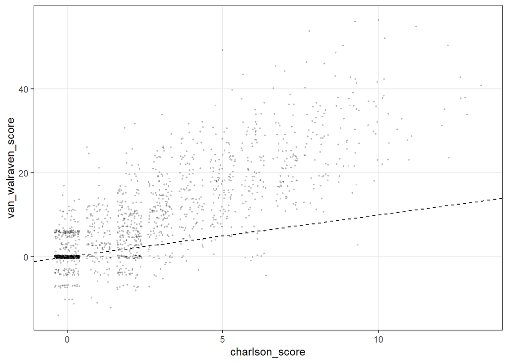

```r
comorb_unique <- full_join(index_scores %>% select(patient_num, charlson_score),
                           index_scores_elix %>% select(patient_num, van_walraven_score),
                           by = "patient_num")

comorb_unique %>%
  ggplot(aes(x = charlson_score, y = van_walraven_score)) +
  geom_jitter(alpha = 0.2, size = 0.3) +
  #coord_fixed() +
  geom_abline(slope = 1, color = 'black', linetype = 'dashed')
```

```r
cor(comorb_unique$charlson_score, comorb_unique$van_walraven_score)
```

```
## [1] 0.8050304
```

## Charlson-Comorbidity matrix

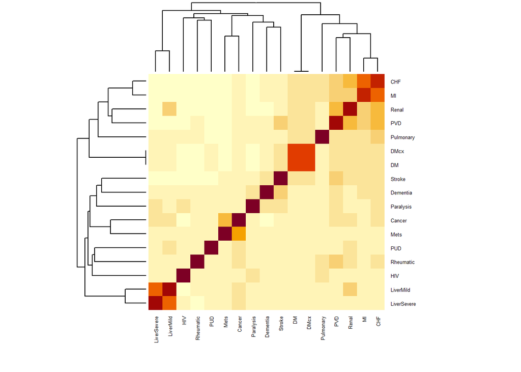

```r
n_comorbs <- colSums(index_scores[, comorbs])
pos_comorbs <- names(n_comorbs[n_comorbs > 0])

index_scores[, pos_comorbs] %>%
  cor() %>%
  heatmap(cexRow = 0.5, cexCol = 0.5)
```

## Charlson & Elixhauser Comorbidities

### Charlson Distribution

The below code will join the comorbidity mappings and the neurological code information, basic demographic and hospital mortality information into one dataframe.

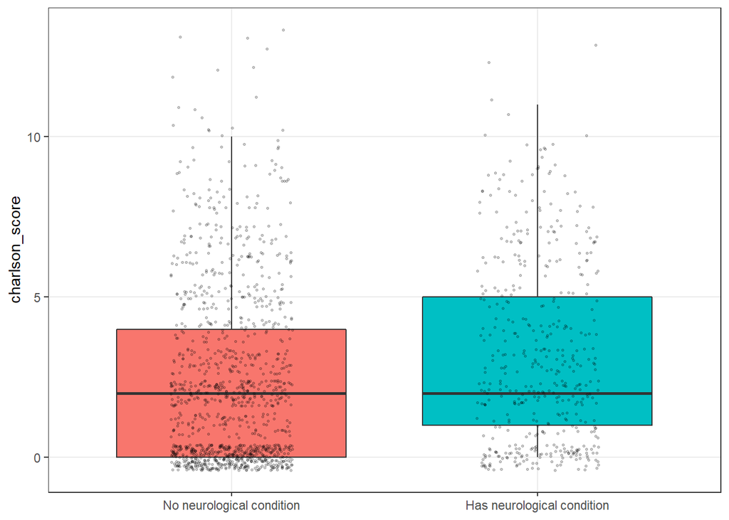

```r
demo_df$patient_num <- as.character(demo_df$patient_num)
obs_raw$patient_num <- as.character(obs_raw$patient_num)

scores_unique <- index_scores %>%
  left_join(demo_df, by = 'patient_num') %>%
  mutate(severe = as.factor(severe) %>%
           fct_recode('Severe' = '1', 'Non-severe' = '0'))

scores_neuro <- obs_raw %>%
  # 1 patient can have different code but each only counted once
  distinct(patient_num, concept_code) %>%
  left_join(neuro_icds_10, by = c('concept_code' = 'icd')) %>%
  left_join(scores_unique, by = 'patient_num') %>%
  filter(!is.na(charlson_score)) %>%
  mutate(concept_code = case_when(
           is.na(`Neurological Disease Category`) ~ 'NN',
           TRUE ~ concept_code) %>%
           as.factor() %>%
           fct_reorder(- charlson_score),
         `Neurological Disease Category` =
           as.factor(`Neurological Disease Category`) %>%
           fct_reorder(charlson_score)) %>%
  {.}

scores_unique %>%
  ggplot(aes(x = neuro_post, y = charlson_score, fill = neuro_post)) +
  geom_boxplot(outlier.colour = NA) +
  geom_jitter(alpha = 0.2, width = 0.2, size = 0.6) +
  guides(fill = FALSE) +
  labs(x = NULL) +
  NULL
```

### Elixhauser Distribution

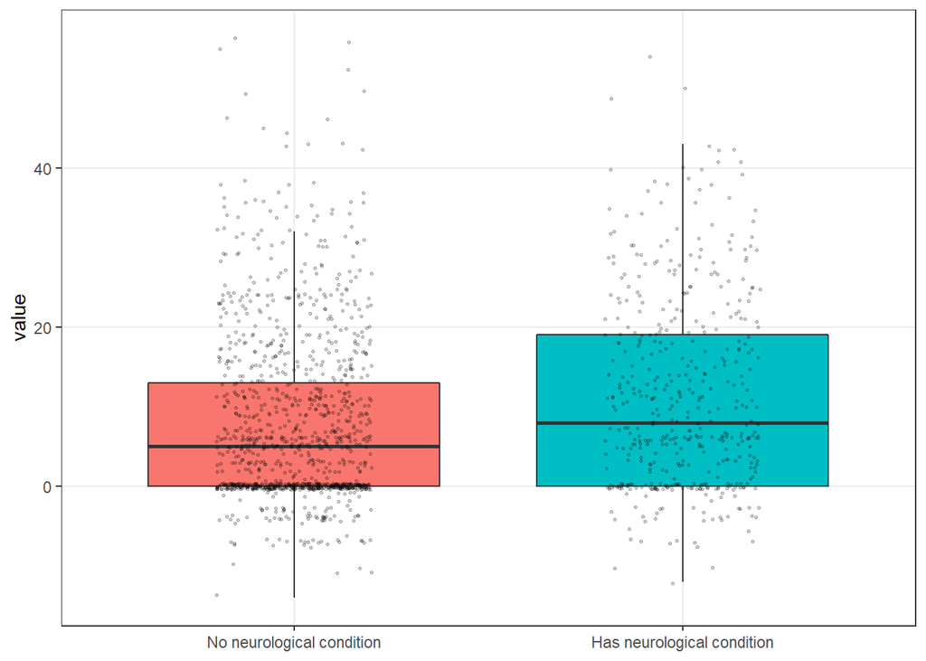

```r
scores_unique_compare <- comorb_unique %>%
  left_join(demo_df, by = 'patient_num') %>%
  mutate(severe = as.factor(severe) %>%
           fct_recode('Severe' = '1', 'Non-severe' = '0')) %>%
  pivot_longer(c(charlson_score, van_walraven_score), "score")

scores_unique_compare %>%
  filter(score == "van_walraven_score") %>%
  ggplot(aes(x = neuro_post, y = value, fill = neuro_post)) +
  geom_boxplot(outlier.colour = NA) +
  geom_jitter(alpha = 0.2, width = 0.2, size = 0.6) +
  guides(fill = FALSE) +
  labs(x = NULL) +
  NULL
```

### Charlson & Elixhauser

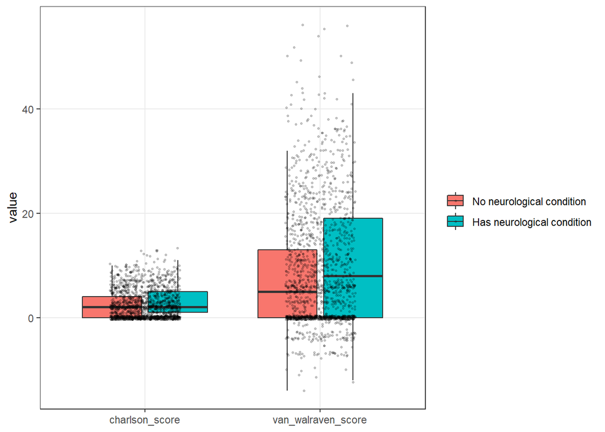

```r
scores_unique_compare %>%
  ggplot(aes(x = score, y = value, fill = neuro_post)) +
  geom_boxplot(outlier.colour = NA) +
  geom_jitter(alpha = 0.2, width = 0.2, size = 0.6) +
  #guides(fill = FALSE) +
  labs(x = NULL) +
  NULL
```

### Charlson Comorbidity table

```r
combined_table1 <- get_table1(
  index_scores %>% filter(patient_num %in% neuro_pt_post),
  comorbidities = comorb_names,
  comorbidities_map = comorb_names$Abbreviation) %>%
  rename('n_neuro_pats' = n_patients) %>%
  left_join(get_table1(index_scores,
            comorbidities = comorb_names,
            comorbidities_map = comorb_names$Abbreviation),
            by = c("Comorbidity", "Abbreviation")) %>%
  mutate(prop_patients = n_patients/nrow(demo_raw),
         prop_neuro_pats = n_neuro_pats/nrow(demo_raw)) %>%
  arrange(desc(n_neuro_pats))

write.csv(combined_table1, "results/table1_combined.csv", row.names = FALSE)

datatable(combined_table1) %>%
  formatPercentage(c('prop_patients', 'prop_neuro_pats'))
```

|  | Comorbidity | Abbreviation | n_neuro_pats | n_patients | prop_patients | prop_neuro_pats |
| --- | --- | --- | --- | --- | --- | --- |
| 1 | Diabetes without complications | DM | 152 | 443 | 0.15963963963964 | 0.0547747747747748 |
| 2 | Diabetes with complications | DMcx | 152 | 443 | 0.15963963963964 | 0.0547747747747748 |
| 3 | Renal Disease | Renal | 147 | 435 | 0.156756756756757 | 0.052972972972973 |
| 4 | Congestive Heart Failure | CHF | 118 | 345 | 0.124324324324324 | 0.0425225225225225 |
| 5 | Periphral Vascular Disease | PVD | 97 | 257 | 0.0926126126126126 | 0.034954954954955 |
| 6 | Myocardial Infarction | MI | 82 | 226 | 0.0814414414414414 | 0.0295495495495495 |
| 7 | Cerebrovascular Disease | Stroke | 81 | 167 | 0.0601801801801802 | 0.0291891891891892 |
| 8 | Chronic Pulmonary Disease | Pulmonary | 76 | 251 | 0.0904504504504505 | 0.0273873873873874 |
| 9 | Cancer | Cancer | 71 | 190 | 0.0684684684684685 | 0.0255855855855856 |
| 10 | Dementia | Dementia | 68 | 124 | 0.0446846846846847 | 0.0245045045045045 |

[output cut: 7 more lines]

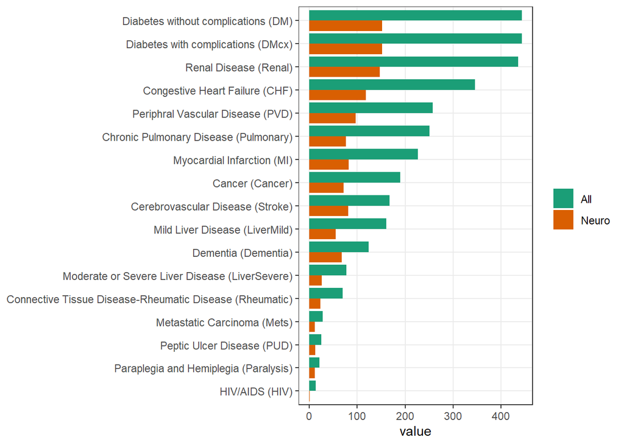

```r
combined_table1 %>%
  pivot_longer(c(n_patients, n_neuro_pats)) %>%
  mutate(fullname = glue::glue('{Comorbidity} ({Abbreviation})')) %>%
  ggplot(aes(x = value, y = fct_reorder(fullname, value), fill = name)) +
  geom_col(position = 'dodge') +
  scale_fill_brewer(palette = 'Dark2', direction = -1,
                    guide = guide_legend(reverse=TRUE),
                    label = c('Neuro', 'All')) +
  labs(y = NULL)
```

### Elixhauser Comorbidity Table

```r
combined_table1_elix <- get_table1(
  index_scores_elix %>% filter(patient_num %in% neuro_pt_post),
  comorbidities = comorb_names_elix,
  comorbidities_map = comorb_names_elix$Abbreviation) %>%
  rename('n_neuro_pats' = n_patients) %>%
  left_join(get_table1(index_scores_elix,
                       comorbidities_map = comorb_names_elix$Abbreviation,
                       comorbidities = comorb_names_elix),
            by = c("Comorbidity", "Abbreviation")) %>%
  mutate(prop_patients = n_patients/nrow(demo_raw),
         prop_neuro_pats = n_neuro_pats/nrow(demo_raw)) %>%
  arrange(desc(n_neuro_pats))

write.csv(combined_table1_elix, "results/table1_combined_elix.csv", row.names = FALSE)

datatable(combined_table1_elix) %>%
  formatPercentage(c('prop_patients', 'prop_neuro_pats'))
```

|  | Comorbidity | Abbreviation | n_neuro_pats | n_patients | prop_patients | prop_neuro_pats |
| --- | --- | --- | --- | --- | --- | --- |
| 1 | Hypertension, combined | HTN | 241 | 671 | 0.241801801801802 | 0.0868468468468468 |
| 2 | Other neurological disorders | NeuroOther | 219 | 564 | 0.203243243243243 | 0.0789189189189189 |
| 3 | Cardiac arrhythmias | Arrhythmia | 176 | 512 | 0.184504504504505 | 0.0634234234234234 |
| 4 | Diabetes, uncomplicated | DM | 152 | 443 | 0.15963963963964 | 0.0547747747747748 |
| 5 | Diabetes, complicated | DMcx | 152 | 443 | 0.15963963963964 | 0.0547747747747748 |
| 6 | Renal failure | Renal | 145 | 429 | 0.154594594594595 | 0.0522522522522523 |
| 7 | Rheumatoid arthritis/collagen vascular diseases | Rheumatic | 144 | 424 | 0.152792792792793 | 0.0518918918918919 |
| 8 | Congestive heart failure | CHF | 118 | 345 | 0.124324324324324 | 0.0425225225225225 |
| 9 | Valvular disease | Valvular | 115 | 307 | 0.110630630630631 | 0.0414414414414414 |
| 10 | Depression | Depression | 104 | 274 | 0.0987387387387387 | 0.0374774774774775 |

[output cut: 20 more lines]

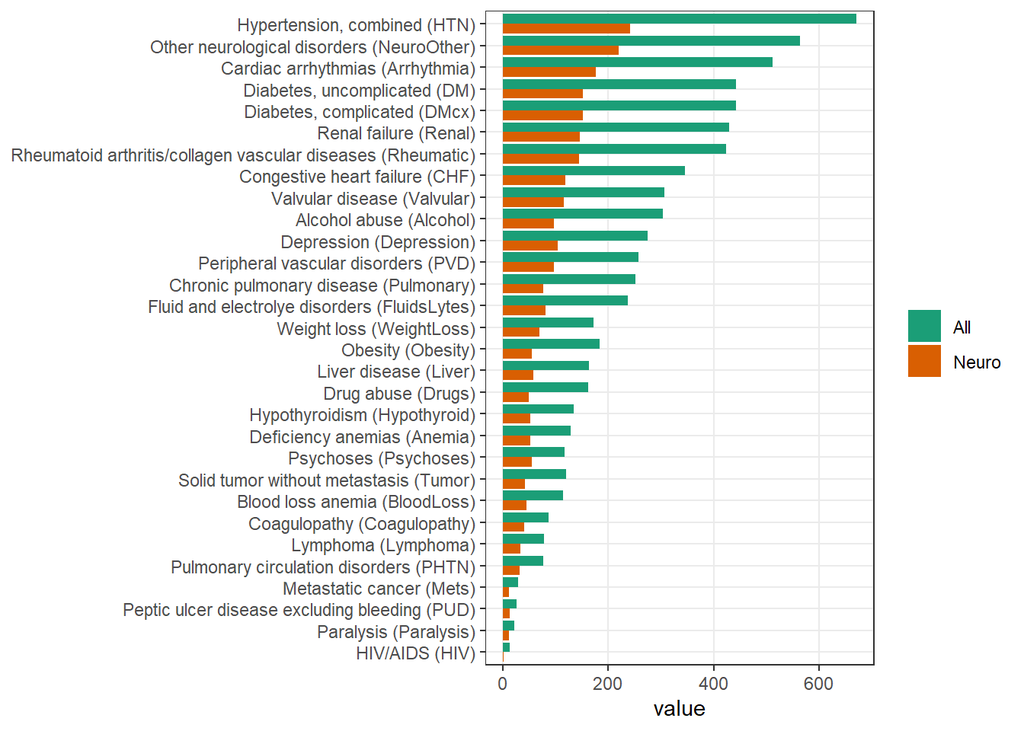

```r
combined_table1_elix %>%
  pivot_longer(c(n_patients, n_neuro_pats)) %>%
  mutate(fullname = glue::glue('{Comorbidity} ({Abbreviation})'))%>%
  ggplot(aes(x = value, y = fct_reorder(fullname, value), fill = name)) +
  geom_col(position = 'dodge') +
  scale_fill_brewer(palette = 'Dark2', direction = -1,
                    guide = guide_legend(reverse=TRUE),
                    label = c('Neuro', 'All')) +
  labs(y = NULL)
```

## Charlson score for each comorbidity type (neuro vs non-neuro)

```r
# Neuro vs non-neuro patients
comorb_long <- scores_unique %>%
  select(patient_num, neuro_post, charlson_score, any_of(pos_comorbs)) %>%
  pivot_longer(any_of(comorbs)) %>%
  filter(value == 1)

comorb_wilcox_func <- function(comorb, df = comorb_long) {
  df <- df %>% filter(name == comorb)
  neuro <- df %>% filter(neuro_post == 'No neurological condition')
  non_neuro <- df %>% filter(neuro_post == 'Has neurological condition')
  try(wilcox.test(neuro$charlson_score, non_neuro$charlson_score)$p.value, silent = TRUE)
}

wilcox_res <- pos_comorbs %>%
  sapply(comorb_wilcox_func, df = comorb_long) %>%
  data.frame(p_value = .) %>%
  cbind(pos_comorbs) %>%
  filter(!(grepl('Error', p_value))) %>%
  arrange(p_value)
wilcox_res
```

```
##                p_value pos_comorbs
## MI          0.01471800          MI
## Renal       0.01900422       Renal
## Pulmonary   0.03304946   Pulmonary
## Mets        0.11245595        Mets
## DM          0.12459159          DM
## DMcx        0.12459159        DMcx
## CHF         0.14692982         CHF
## LiverMild   0.18621795   LiverMild
## LiverSevere 0.30796477 LiverSevere
## HIV         0.54077747         HIV
## Dementia    0.54139805    Dementia
## PUD         0.78398151         PUD
## Cancer      0.81760606      Cancer
## Rheumatic   0.84364325   Rheumatic
## Stroke      0.90132380      Stroke
## PVD         0.96801565         PVD
## Paralysis   1.00000000   Paralysis
```

## Short term outcomes

Do hospitalized COVID-19 patients with neurological conditions have a different short-term natural history (hospital days, death, severity, readmission) from those without?

Resolution: Charlson score vs comorbidity type, Neurological condition (TRUE/FALSE) vs. neurological ICD code?

### Severity, Death

**Charlson**

```r
severe_reg <- glm(severe ~ neuro_post + charlson_score + sex + age_group + race,
   data = scores_unique, family = 'binomial') %>%
  tidy()
severe_reg
```

```
## # A tibble: 16 x 5
##    term                                 estimate std.error statistic  p.value
##    <chr>                                   <dbl>     <dbl>     <dbl>    <dbl>
##  1 (Intercept)                           -1.50      1.54     -0.973  3.31e- 1
##  2 neuro_postHas neurological condition   0.819     0.120     6.84   7.83e-12
##  3 charlson_score                         0.0841    0.0201    4.18   2.98e- 5
##  4 sexmale                                0.0265    0.106     0.249  8.03e- 1
##  5 age_group06to11                        0.0465    1.51      0.0308 9.75e- 1
##  6 age_group12to17                      -13.7     393.       -0.0349 9.72e- 1
##  7 age_group18to25                        1.42      0.905     1.57   1.16e- 1
##  8 age_group26to49                        0.542     0.875     0.620  5.35e- 1
##  9 age_group50to69                        0.498     0.875     0.569  5.69e- 1
## 10 age_group70to79                        0.608     0.881     0.690  4.90e- 1
## 11 age_group80plus                        0.276     0.883     0.313  7.54e- 1
## 12 raceasian                              0.971     1.30      0.748  4.54e- 1
## 13 raceblack                              0.797     1.27      0.625  5.32e- 1
## 14 racehawaiian_pacific_islander         -1.38      1.69     -0.814  4.16e- 1
## 15 raceother                              0.949     1.28      0.743  4.58e- 1
## 16 racewhite                              0.585     1.27      0.461  6.45e- 1
```

```r
deceased_reg <- glm(deceased ~ neuro_post + charlson_score + sex + age_group + race,
   data = scores_unique, family = 'binomial') %>%
  tidy()
deceased_reg
```

```
## # A tibble: 16 x 5
##    term                                 estimate std.error  statistic   p.value
##    <chr>                                   <dbl>     <dbl>      <dbl>     <dbl>
##  1 (Intercept)                          -30.9    1657.     -0.0186    0.985
##  2 neuro_postHas neurological condition   0.260     0.191   1.37      0.172
##  3 charlson_score                         0.118     0.0301  3.92      0.0000896
##  4 sexmale                                0.422     0.188   2.24      0.0249
##  5 age_group06to11                       -0.0735 1648.     -0.0000446 1.00
##  6 age_group12to17                        0.0520 1420.      0.0000366 1.00
##  7 age_group18to25                       12.3     951.      0.0129    0.990
##  8 age_group26to49                       12.2     951.      0.0128    0.990
##  9 age_group50to69                       13.6     951.      0.0143    0.989
## 10 age_group70to79                       14.0     951.      0.0147    0.988
## 11 age_group80plus                       14.7     951.      0.0155    0.988
## 12 raceasian                             13.5    1357.      0.00992   0.992
## 13 raceblack                             13.9    1357.      0.0102    0.992
## 14 racehawaiian_pacific_islander          0.367  1636.      0.000224  1.00
## 15 raceother                             12.9    1357.      0.00952   0.992
## 16 racewhite                             14.4    1357.      0.0106    0.992
```

**Elixhauser**

```r
scores_unique_elix <- scores_unique_compare %>%
  filter(score == "van_walraven_score") %>%
  rename("ElixhauserScore" = value)

severe_reg_elix <- glm(severe ~ neuro_post + ElixhauserScore + sex + age_group + race,
   data = scores_unique_elix, family = 'binomial') %>%
  tidy()
severe_reg_elix
```

```
## # A tibble: 16 x 5
##    term                                 estimate std.error statistic  p.value
##    <chr>                                   <dbl>     <dbl>     <dbl>    <dbl>
##  1 (Intercept)                           -1.67     1.54      -1.09   2.77e- 1
##  2 neuro_postHas neurological condition   0.814    0.120      6.80   1.06e-11
##  3 ElixhauserScore                        0.0215   0.00500    4.29   1.75e- 5
##  4 sexmale                                0.0334   0.106      0.315  7.53e- 1
##  5 age_group06to11                        0.0169   1.51       0.0112 9.91e- 1
##  6 age_group12to17                      -13.6    391.        -0.0348 9.72e- 1
##  7 age_group18to25                        1.49     0.907      1.65   9.98e- 2
##  8 age_group26to49                        0.630    0.876      0.719  4.72e- 1
##  9 age_group50to69                        0.601    0.875      0.687  4.92e- 1
## 10 age_group70to79                        0.713    0.881      0.810  4.18e- 1
## 11 age_group80plus                        0.355    0.883      0.402  6.88e- 1
## 12 raceasian                              1.10     1.30       0.847  3.97e- 1
## 13 raceblack                              0.914    1.27       0.718  4.73e- 1
## 14 racehawaiian_pacific_islander         -1.27     1.69      -0.750  4.53e- 1
## 15 raceother                              1.04     1.28       0.818  4.13e- 1
## 16 racewhite                              0.684    1.27       0.539  5.90e- 1
```

```r
deceased_reg_elix <- glm(deceased ~ neuro_post + ElixhauserScore + sex + age_group + race,
   data = scores_unique_elix %>% filter(score == "van_walraven_score"), family = 'binomial') %>%
  tidy()
deceased_reg_elix
```

```
## # A tibble: 16 x 5
##    term                                 estimate  std.error  statistic  p.value
##    <chr>                                   <dbl>      <dbl>      <dbl>    <dbl>
##  1 (Intercept)                          -31.2    1651.      -0.0189    0.985
##  2 neuro_postHas neurological condition   0.247     0.191    1.30      0.194
##  3 ElixhauserScore                        0.0257    0.00745  3.46      0.000549
##  4 sexmale                                0.444     0.188    2.37      0.0180
##  5 age_group06to11                       -0.105  1646.      -0.0000638 1.00
##  6 age_group12to17                        0.217  1418.       0.000153  1.00
##  7 age_group18to25                       12.4     950.       0.0130    0.990
##  8 age_group26to49                       12.3     950.       0.0130    0.990
##  9 age_group50to69                       13.8     950.       0.0145    0.988
## 10 age_group70to79                       14.2     950.       0.0150    0.988
## 11 age_group80plus                       14.9     950.       0.0157    0.987
## 12 raceasian                             13.7    1350.       0.0101    0.992
## 13 raceblack                             14.1    1350.       0.0105    0.992
## 14 racehawaiian_pacific_islander          0.548  1627.       0.000337  1.00
## 15 raceother                             13.1    1350.       0.00969   0.992
## 16 racewhite                             14.6    1350.       0.0108    0.991
```

### Length of stay

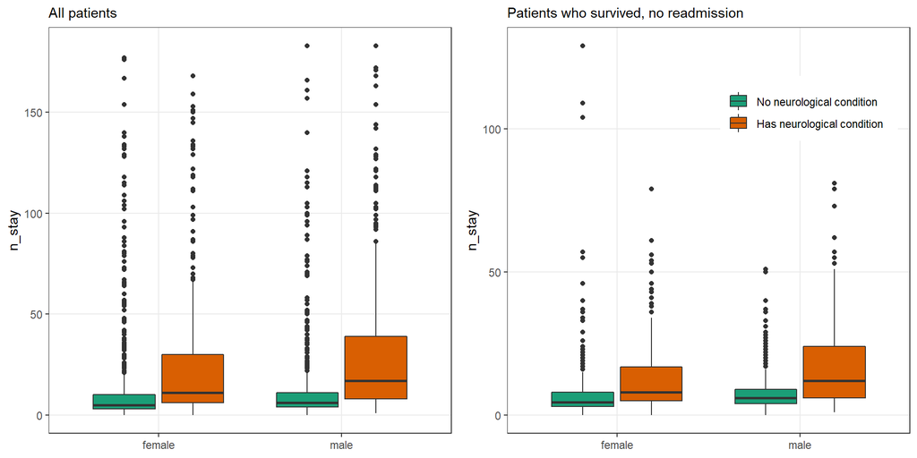

```r
left_stay <- demo_df %>%
  ggplot(aes(x = sex, y = n_stay, fill = neuro_post)) +
  geom_boxplot() +
  scale_fill_brewer(palette = 'Dark2', guide = FALSE) +
  labs(x = NULL , subtitle = 'All patients') +
  NULL

right_stay <- demo_df %>%
  filter(!readmitted, !deceased) %>%
  ggplot(aes(x = sex, y = n_stay, fill = neuro_post)) +
  geom_boxplot() +
  scale_fill_brewer(palette = 'Dark2') +
  labs(x = NULL , subtitle =  'Patients who survived, no readmission') +
  theme(legend.position = c(0.75, 0.8)) +
  NULL
plot_grid(left_stay, right_stay)
```

**Charlson**

```r
n_stay_reg <- lm(n_stay ~ neuro_post + charlson_score + race + sex + age_group,
   data = scores_unique) %>%
  tidy()

n_stay_reg
```

```
## # A tibble: 16 x 5
##    term                                 estimate std.error statistic  p.value
##    <chr>                                   <dbl>     <dbl>     <dbl>    <dbl>
##  1 (Intercept)                            -4.49     20.1      -0.224 8.23e- 1
##  2 neuro_postHas neurological condition   15.2       1.61      9.49  8.44e-21
##  3 charlson_score                          2.04      0.275     7.39  2.32e-13
##  4 raceasian                              14.0      16.8       0.834 4.05e- 1
##  5 raceblack                              11.3      16.4       0.684 4.94e- 1
##  6 racehawaiian_pacific_islander          14.1      20.1       0.705 4.81e- 1
##  7 raceother                               3.97     16.5       0.241 8.10e- 1
##  8 racewhite                               5.30     16.4       0.324 7.46e- 1
##  9 sexmale                                 0.911     1.48      0.617 5.37e- 1
## 10 age_group06to11                         2.68     20.0       0.134 8.93e- 1
## 11 age_group12to17                         3.46     18.3       0.189 8.50e- 1
## 12 age_group18to25                         6.40     12.0       0.532 5.94e- 1
## 13 age_group26to49                         7.55     11.7       0.648 5.17e- 1
## 14 age_group50to69                         6.09     11.6       0.523 6.01e- 1
## 15 age_group70to79                         7.26     11.7       0.618 5.37e- 1
## 16 age_group80plus                         3.08     11.8       0.262 7.94e- 1
```

**Elixhauser**

```r
n_stay_reg_elix <- lm(n_stay ~ neuro_post + ElixhauserScore + race + sex + age_group,
   data = scores_unique_elix) %>%
  tidy()

n_stay_reg_elix
```

```
## # A tibble: 16 x 5
##    term                                 estimate std.error statistic  p.value
##    <chr>                                   <dbl>     <dbl>     <dbl>    <dbl>
##  1 (Intercept)                            -8.64    20.0      -0.432  6.66e- 1
##  2 neuro_postHas neurological condition   15.0      1.60      9.37   2.52e-20
##  3 ElixhauserScore                         0.545    0.0678    8.05   1.66e-15
##  4 raceasian                              17.1     16.7       1.02   3.07e- 1
##  5 raceblack                              13.9     16.4       0.849  3.96e- 1
##  6 racehawaiian_pacific_islander          16.8     20.0       0.841  4.00e- 1
##  7 raceother                               6.23    16.4       0.379  7.04e- 1
##  8 racewhite                               7.64    16.3       0.468  6.40e- 1
##  9 sexmale                                 0.961    1.47      0.653  5.14e- 1
## 10 age_group06to11                         1.89    20.0       0.0946 9.25e- 1
## 11 age_group12to17                         7.17    18.2       0.393  6.94e- 1
## 12 age_group18to25                         8.10    12.0       0.676  4.99e- 1
## 13 age_group26to49                         9.60    11.6       0.827  4.08e- 1
## 14 age_group50to69                         8.45    11.6       0.728  4.66e- 1
## 15 age_group70to79                         9.62    11.7       0.823  4.10e- 1
## 16 age_group80plus                         4.68    11.7       0.400  6.89e- 1
```

### By Neuro Diagnosis

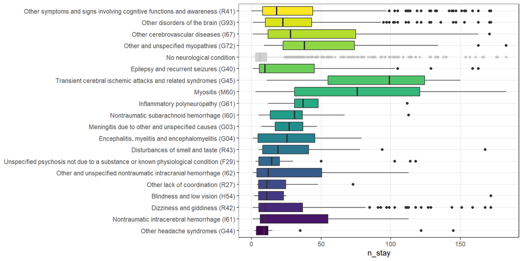

```r
demo_df$patient_num <- as.numeric(demo_df$patient_num)

nstay_df <- neuro_patients %>%
  bind_rows(non_neuro_patients) %>%
  left_join(demo_df, by = 'patient_num') %>%
  # mutate(concept_code = fct_reorder(concept_code, n_stay)) %>%
  left_join(neuro_icds_10, by = c('concept_code' = 'icd')) %>%
  mutate(full_icd = case_when(
    concept_code == 'NN' ~ 'No neurological condition',
    TRUE ~ paste0(`ICD-10 Description`, ' (', concept_code, ')')) %>%
             as.factor() %>% fct_reorder(n_stay))

nstay_df %>%
  ggplot(aes(y = full_icd, x = n_stay, fill = full_icd)) +
  labs(y = NULL) +
  geom_boxplot() +
  scale_fill_viridis_d(guide = FALSE) +
  gghighlight(concept_code != 'NN') +
  NULL
```

```r
summarised_stay <- nstay_df %>%
  group_by(concept_code) %>%
  summarise(mean_stay = mean(n_stay),
            sd_stay = sd(n_stay),
            n_patients = n(),
            .groups = 'drop')
```

## Comorbidities by Diagnosis

Here we will use the `obs_processed` dataframe in contrast to our `scores_unique` dataframe as the former is in long format

**Charlson**

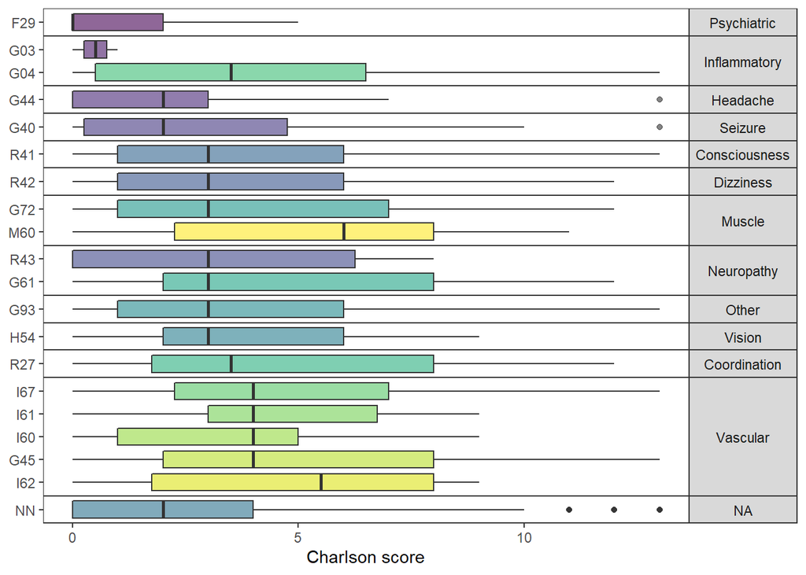

```r
# scores$patient_num <- as.numeric(as.character(scores$patient_num))
scores_neuro %>%
  distinct(patient_num, concept_code, `Neurological Disease Category`, charlson_score) %>%
  filter(!is.na(charlson_score)) %>%
  ggplot(aes(y = concept_code, x = charlson_score, fill = concept_code)) +
  facet_grid(rows = vars(`Neurological Disease Category`),
             scales = 'free', space = 'free') +
  geom_boxplot(alpha = 0.6) +
  scale_fill_viridis_d(guide = FALSE, direction = -1) +
  labs(x = 'Charlson score', y = NULL) +
  NULL +
  theme(panel.grid = element_blank(),
        legend.title = element_text(),
        strip.text.y = element_text(angle = 0),
        panel.spacing.x = unit(10, "points"),
        panel.spacing.y = unit(0, "points"))
```

**Elixhauser**

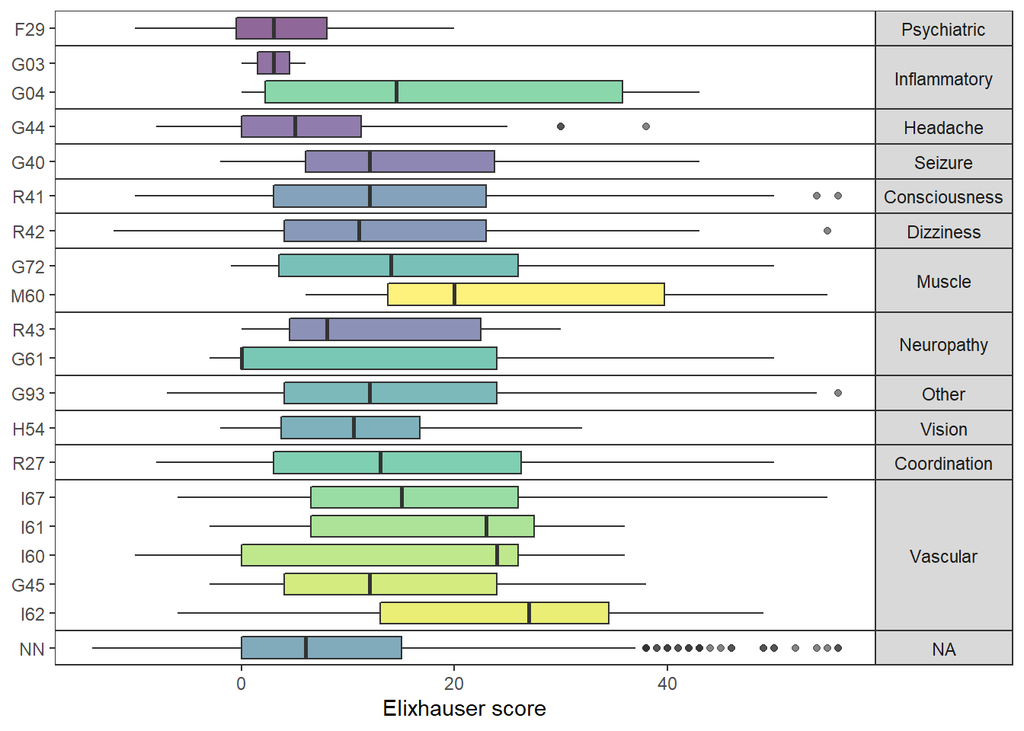

```r
scores_neuro %>%
  distinct(patient_num, concept_code, `Neurological Disease Category`) %>%
  left_join(index_scores_elix %>% select(patient_num, van_walraven_score), by = "patient_num") %>%
  filter(!is.na(van_walraven_score)) %>%
  ggplot(aes(y = concept_code, x = van_walraven_score, fill = concept_code)) +
  facet_grid(rows = vars(`Neurological Disease Category`),
             scales = 'free', space = 'free') +
  geom_boxplot(alpha = 0.6) +
  scale_fill_viridis_d(guide = FALSE, direction = -1) +
  labs(x = 'Elixhauser score', y = NULL) +
  NULL +
  theme(panel.grid = element_blank(),
        legend.title = element_text(),
        strip.text.y = element_text(angle = 0),
        panel.spacing.x = unit(10, "points"),
        panel.spacing.y = unit(0, "points"))
```

## Evaluating Timeframe of Comorbidities

Qs: When are these comorbidities getting mapped. Understanding ICD code assignnment can help us prevent confusing complications with comorbidities and vice versa.

It would be helpful to review the literature as well, what did the original developers of the comorbidity indexes do? How were they validated?

## First occurence of a comorbidity

The below figure plots the first time a patient had an ICD code map to that specific comorbidity.

Perhaps could go a conservative route and only include comorbidities if there was a previous record of it? However, each comorbidity category can contain multiple different types of diseases. So perhaps could be problematic.

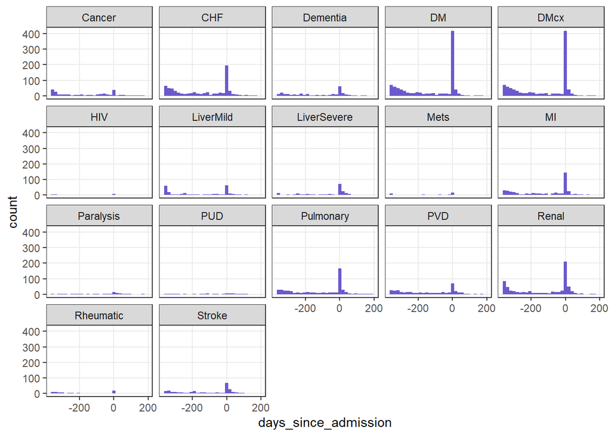

```r
obs_first <- obs_raw %>%
  group_by(patient_num) %>%
  merge(mapped_codes_table, by = "concept_code") %>%
  arrange(days_since_admission) %>%
  group_by(patient_num, Abbreviation) %>%
  mutate(first_occurence = min(days_since_admission),
         first_occurence_indicator = if_else(first_occurence == days_since_admission, 1, 0)) %>%
  ungroup()  %>%
  filter(first_occurence_indicator == 1)

ggplot(obs_first, aes(x = days_since_admission)) +
  geom_histogram(fill = 'slateblue') +
   facet_wrap(~Abbreviation)
```

## Neuro Patients timeline of first neuro diagnosis

If this is helpful, we may want to move to the explore-neuro.rmd file.

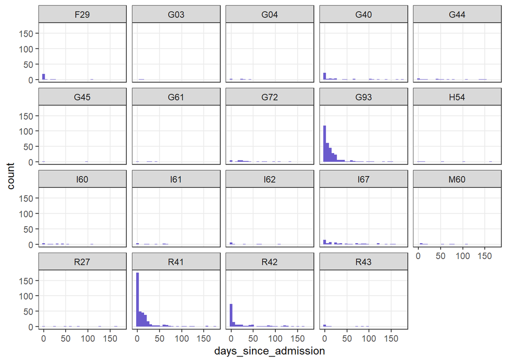

```r
post_adm_neuro_pats <- obs_raw %>%
  filter(days_since_admission >= 0) %>%
  right_join(neuro_icds_10, by = c('concept_code' = 'icd')) %>%
  group_by(patient_num, concept_code) %>%
  mutate(first_occurence = min(days_since_admission),
         first_occurence_indicator = if_else(first_occurence == days_since_admission, 1, 0)) %>%
  ungroup()  %>%
  filter(first_occurence_indicator == 1)

ggplot(post_adm_neuro_pats, aes(x = days_since_admission)) +
  geom_histogram(fill = 'slateblue') +
   facet_wrap(~concept_code)
```

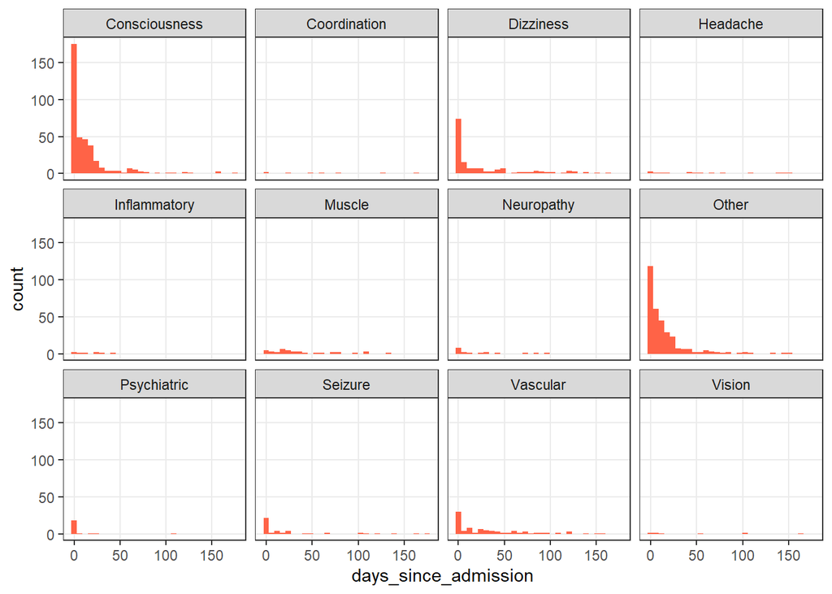

```r
ggplot(post_adm_neuro_pats, aes(x = days_since_admission)) +
  geom_histogram(fill = 'tomato') +
   facet_wrap(~`Neurological Disease Category`)
```

## Additional Notes:

Neuro Codes: G04, G45, G46, I60, 161, 162, and 167 will map to comorbidities. An important consideration is that we don’t want to confuse comorbidities for complications of hospital stay/COVID-19

The below will assess how many on these neuro comorbidity codes occurred on the day of admission and how many neuro codes in general are on the day of admission.

*Note: This is just for data exploration right now, we are going to initially just assume that any codes prior to the COVID-19 admission are comorbidities*

```r
neuro_comorb_codes <- c("G04", "G45", "G46",  # paralysis codes
                        "I60", "161", "162", "167") # stroke codes

neuro_comorb_on_admission <- obs_raw %>%
  filter(days_since_admission == 0) %>%
  filter(concept_code %in% neuro_comorb_codes) %>%
  select(patient_num, concept_code) %>%
  distinct()
unique(neuro_comorb_on_admission$concept_code)
```

```
## [1] "162" "I60" "G04"
```

```r
# penn
summarised_stay_penn = summarised_stay
n_stay_reg_penn = n_stay_reg
severe_reg_penn = severe_reg
deceased_reg_penn = deceased_reg
table_one_penn = table_one
write.csv(table_one_penn, file = "results/penn-table1.csv")

save(summarised_stay_penn,
     severe_reg_penn,
     deceased_reg_penn,
     table_one_penn,
     n_stay_reg_penn,
     file = 'results/penn-results.rda')

# nwu
summarised_stay_nwu = summarised_stay
n_stay_reg_nwu = n_stay_reg
severe_reg_nwu = severe_reg
deceased_reg_nwu = deceased_reg
table_one_nwu = table_one
write.csv(table_one_nwu, file = "results/nwu-table1.csv")

save(summarised_stay_nwu,
     severe_reg_nwu,
     deceased_reg_nwu,
     table_one_nwu,
     n_stay_reg_nwu,
     file = 'results/nwu-results.rda')
```